# Lab04 - COEFICIENTE DE CORRELACIÓN

Escriba Flores, Daniel Agustin

2025-04-13

# Contexto:

El director del Zoológico de Tampa estudia la relación entre el número de visitantes, en miles, y la temperatura alta, en grados Fahrenheit. Selecciona una muestra de 15 días y la información muestral recopilada se tabula a continuación:

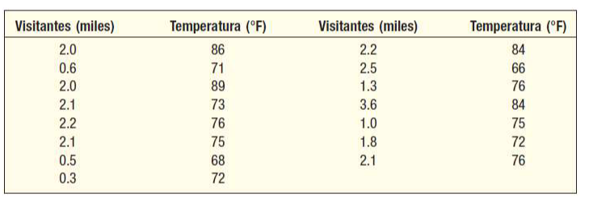

De acuerdo a lo anterior, haga lo siguiente:

# Pregunta A: Diagrama de dispersion

1. Traslade la información de la tabla mostrada a un documento de Excel, asígnele el nombre ‘zoológico.xlsx’, lea la base de datos y elabore un diagrama de dispersión para las variables numéricas.

## Lectura de datos

```r
library(readxl) #Llamamos a la liberia

data = read_excel("zoologico.xlsx", sheet="Hoja1")
data = data[-1]
data = as.data.frame(data)
data
```

```
##    visitantes temperatura
## 1         2.0          86
## 2         0.6          71
## 3         2.0          89
## 4         2.1          73
## 5         2.2          76
## 6         2.1          75
## 7         0.5          68
## 8         0.3          72
## 9         2.2          84
## 10        2.5          66
## 11        1.3          76
## 12        3.6          84
## 13        1.0          75
## 14        1.8          72
## 15        2.1          76
```

## Diagrama

elaboramos

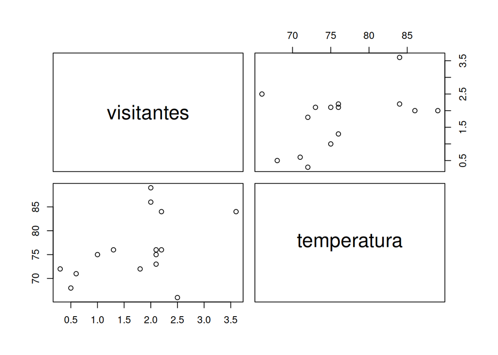

```r
pairs(data)
```

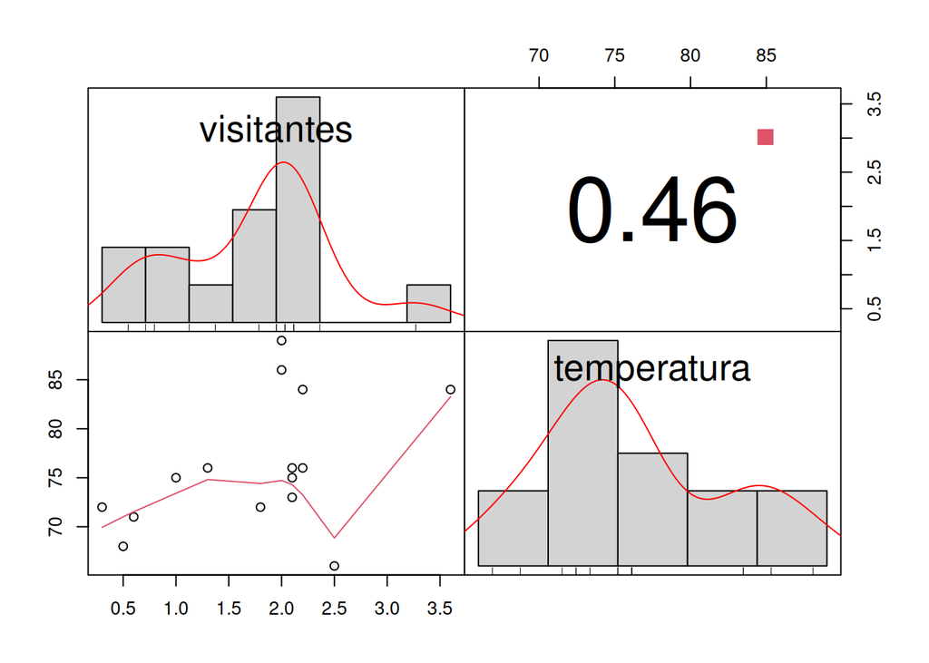

```r
# llamamos a la libreria para utilizar PerformanceAnalytics
library(PerformanceAnalytics)


chart.Correlation(data)
```

# Pregunta B: Correlacion y determinacion

2. Calcule e interprete el coeficiente de correlación y el de determinación.

```r
cor(data) # Matriz de correlación
```

```
##             visitantes temperatura
## visitantes   1.0000000   0.4567093
## temperatura  0.4567093   1.0000000
```

Para calcular el coeficiente de determinación solo debemos elevar al cuadrado el valor del coeficiente de correlación.

```r
x = data$temperatura
y = data$visitantes

coef_corr = cor(x, y, method = "pearson")
coef_corr # Coeficiente de correlacion
```

```
## [1] 0.4567093
```

```r
coef_deter = coef_corr^2
coef_deter # Coeficiente de determinacion
```

```
## [1] 0.2085834
```

## Interpretacion:

- Coeficiente de correlación (r = 0.457): Indica una relación positiva, pero moderadamente débil, entre la temperatura y el número de visitantes. Esto sugiere que, aunque días más cálidos tienden a atraer más público al zoológico, el efecto no es particularmente fuerte ni consistente.
- Coeficiente de determinación (R² = 0.209): Revela que solo el 20.9% de las variaciones en la asistencia pueden atribuirse a cambios en la temperatura. La mayor parte (79.1%) depende de otros factores no considerados en este análisis, como días festivos, promociones, condiciones climáticas adicionales (lluvia, humedad) o temporadas escolares.

# Pregunta C: Prueba de normalidad

3. Realice la prueba de normalidad Shapiro-Wilk y diga si estas siguen o no una distribución normal.

```r
shapiro.test(x)
```

```
##
##  Shapiro-Wilk normality test
##
## data:  x
## W = 0.92746, p-value = 0.25
```

## Interpretación:

El valor p (0.25) es mayor que el nivel de significancia típico ($\alpha$ = 0.05). Esto indica que no hay evidencia suficiente para rechazar la hipótesis nula de normalidad.